# WinsRegression

```r
# install.packages("hoopR")
library(hoopR)
library(tidyverse)
library(pander)
library(ResourceSelection)
```

# Results and food for thought

I tested the effect that 4 different types of scores have on the probability of an NBA team winning. The results show that 3 point makes have the greatest effect on the odds of a team winning in the NBA. For every 3 pointer made, the odds of an NBA team winning go up by 31%. Thankfully, the Bulls have already been putting work into this trend, increasing their average three point makes by 4, or from 11 last year to 15 this year. The next best increase in odds of winning is from every free throw made, with a 9% increase in odds of winning for every free throw made. This is where the Bulls have struggled. They only make 15 free throws (second worst in the league) on average despite averaging 49 points in the paint (13th in the league). It’s something to work on given it’s even more important to the odds of winning than points in the paint. Lastly, fast break points only increase the odds of winning by 2%.

In future work, we would like to implement defensive stats and see how those also effect the odds of winning.

## Model

By calculating the exponents of the coefficients for each variables effect on the model, we can come up with a probability that $Y_i$, or the team_winner variable being true, is actually true.

$$P(Y_i = 1|\, x_i) = \frac{e^{\beta_0 + \beta_i x_i}}{1+e^{\beta_0 +
\beta_i x_i}} = \pi_i$$

## Hypotheses

The null hypotheses of this test was that none of the $\beta_i$ or the X variables is different from 0. In other words they do not change the probability of a team winning when they increase by one with all other variables being held constant. The alternative hypotheses is that at least one of the $\beta_i$ or X variables estimated change in the log of the odds of winning is different from 0. The level of significance is .05 for this test. $\beta_0$ will not be significant to this test because very few teams if any would every score 0 in any of these categories.

$$H_o: \beta_i = 0$$
$$\beta_i \neq 0$$
$$\alpha = .05$$

## Data

This data was grabbed from the ‘hoopsR’ package in R. It scrapes ESPN for the latest in season box scores data from the NBA.

```r
nba <- load_nba_team_box(seasons = most_recent_nba_season())

nba_filter <- nba %>%
  filter(team_id < 31) %>%
  mutate(points_in_paint = as.numeric(points_in_paint), fast_break_points = as.numeric(fast_break_points)) %>%
  drop_na()

bulls_filter <- nba_filter %>%
  filter(team_abbreviation == "CHI")
```

## Numerical Summary

We can see here that the p-value is significantly smaller than the level of significance for each variable. This means that each variable does have a significant effect on the odds of the team winning. This would also mean we reject the null hypotheses, and that the X variables, $\beta_i$, are different from 0.

```r
nba.glm <- glm(team_winner == "TRUE" ~ points_in_paint+free_throws_made+three_point_field_goals_made+fast_break_points, data = nba_filter, family = binomial)

pander(summary(nba.glm))
```

|  | Estimate | Std. Error | z value | Pr(>\|z\|) |
| --- | --- | --- | --- | --- |
| **(Intercept)** | -9.329 | 0.492 | -18.96 | 3.492e-80 |
| **points_in_paint** | 0.07567 | 0.005797 | 13.05 | 6.046e-39 |
| **free_throws_made** | 0.09183 | 0.009109 | 10.08 | 6.693e-24 |
| **three_point_field_goals_made** | 0.2735 | 0.01587 | 17.24 | 1.373e-66 |
| **fast_break_points** | 0.02466 | 0.008037 | 3.068 | 0.002156 |

(Dispersion parameter for binomial family taken to be 1 )

| Null deviance: | 3075 on 2217 degrees of freedom |
| --- | --- |
| Residual deviance: | 2540 on 2213 degrees of freedom |

```r
palette(c("firebrick", "green", "black", "darkorchid4"))
b <- coef(nba.glm)
pander(b)
```

Table continues below

| (Intercept) | points_in_paint | free_throws_made |
| --- | --- | --- |
| -9.329 | 0.07567 | 0.09183 |

| three_point_field_goals_made | fast_break_points |
| --- | --- |
| 0.2735 | 0.02466 |

## Graphical Summary

This graph shows the stark difference that three point makes has over the odds of winning compared to the other 3 types of scores. There’s a noticeable gap between the uptick in the odds of winning between 3 point makes and free throw makes. Points in the paint, and fast break points take a lot more makes/points in order to start effecting the odds of winning significantly.

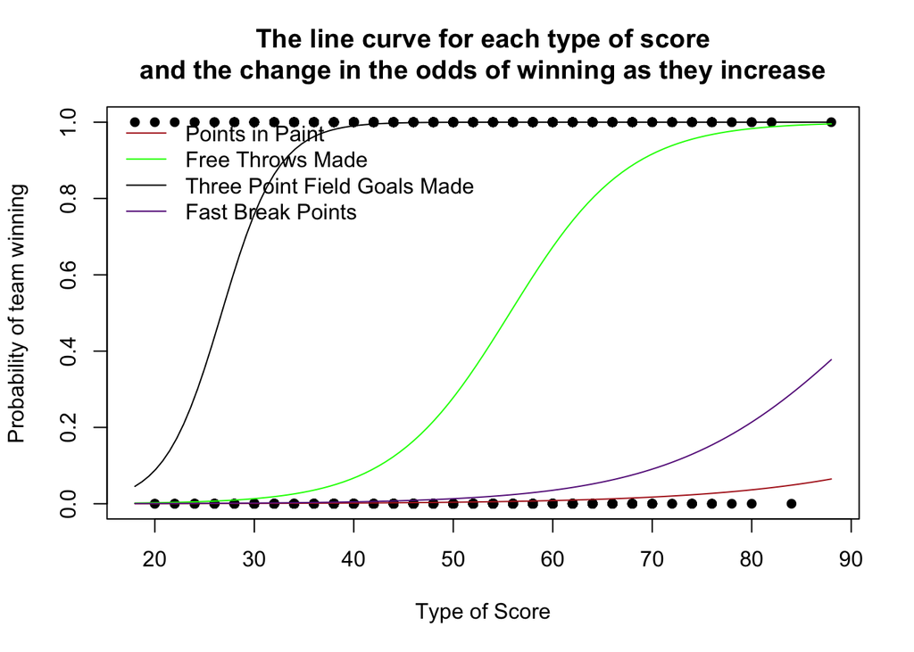

```r
plot(team_winner == "TRUE" ~ points_in_paint, data = nba_filter, pch=16, ylab= "Probability of team winning", xlab = "Type of Score")
curve(exp(b[1]+b[2]*x)/(1+exp(b[1]+b[2]*x)), add=TRUE, col = palette()[1])
curve(exp((b[1])+(b[2]+b[3])*x)/(1+exp((b[1])+(b[2]+b[3])*x)), add=TRUE, col = palette()[2])
curve(exp((b[1])+(b[2]+b[4])*x)/(1+exp((b[1])+(b[2]+b[4])*x)), add=TRUE, col = palette()[3])
curve(exp((b[1])+(b[2]+b[5])*x)/(1+exp((b[1])+(b[2]+b[5])*x)), add=TRUE, col = palette()[4])

legend("topleft", legend = c("Points in Paint" ,"Free Throws Made", "Three Point Field Goals Made", "Fast Break Points"), col = palette(), lty = 1, bty = 'n')

title(main = "The line curve for each type of score\nand the change in the odds of winning as they increase")
```

## Change in the log of the odds for each type of score

Here is where we got the % increase for each type of score in the odds of winning. Taking the exponent of each coefficient gives us that number. Because they are all over 1, this means they effect the odds of winning positively. Therefore, we can subtract their number by 1 and then times it by 100 to get the percentage increase in the odds of winning.

```r
pander(exp(b[2]))
```

| points_in_paint |
| --- |
| 1.079 |

```r
pander(exp(b[3]))
```

| free_throws_made |
| --- |
| 1.096 |

```r
pander(exp(b[4]))
```

| three_point_field_goals_made |
| --- |
| 1.315 |

```r
pander(exp(b[5]))
```

| fast_break_points |
| --- |
| 1.025 |

## Diagnosing the fit of the model

```r
hoslem.test(nba.glm$y, nba.glm$fitted, g=10) %>% pander()
```

| Test statistic | df | P value |
| --- | --- | --- |
| 4.889 | 8 | 0.7694 |

```r
bulls_averages <- bulls_filter %>%
  group_by(team_abbreviation) %>%
  summarise(avg_pip = mean(points_in_paint), avg_threes = mean(three_point_field_goals_made), avg_fts = mean(free_throws_made), avg_fb = mean(fast_break_points))

avg_pip <- bulls_averages$avg_pip
avg_threes <- bulls_averages$avg_threes
avg_fts <- bulls_averages$avg_fts
avg_fb <- bulls_averages$avg_fb


pander(predict(nba.glm, newdata = data.frame(points_in_paint = avg_pip, three_point_field_goals_made = avg_threes, free_throws_made = avg_fts, fast_break_points = avg_fts), type = "response"))
```

| 1 |
| --- |
| 0.6362 |